# Titanic

##Content

[output not shown]

##Introduction

1.1 Objective

The sinking of the RMS Titanic is one of the most infamous shipwrecks in history. On April 15, 1912, during her maiden voyage, the Titanic sank after colliding with an iceberg, killing 1502 out of 2224 passengers and crew. This sensational tragedy shocked the international community and led to better safety regulations for ships.

One of the reasons that the shipwreck led to such loss of life was that there were not enough lifeboats for the passengers and crew. Although there was some element of luck involved in surviving the sinking, some groups of people were more likely to survive than others, such as women, children, and the upper-class.

In this challenge, we are going to complete the analysis of what sorts of people were likely to survive. 1.2 Data Understanding

To download data, click here

The data has been split into two groups:

```
training set (train.csv)
test set (test.csv)
```

The training set is used to build machine learning models. For the training set, we provide the outcome (also known as the “ground truth”) for each passenger. Your model will be based on “features” like passengers’ gender and class. You can also use feature engineering to create new features.

The test set should be used to see how well your model performs on unseen data. For the test set, we do not provide the ground truth for each passenger. It is your job to predict these outcomes. For each passenger in the test set, use the model you trained to predict whether or not they survived the sinking of the Titanic.

##Data Dictionary

Variable Definition Key survival - Survival 0 = No, 1 = Yes pclass - Ticket class 1 = 1st, 2 = 2nd, 3 = 3rd sex - Sex  
Age - Age in years  
sibsp - # of siblings / spouses aboard the Titanic  
parch - # of parents / children aboard the Titanic  
ticket Ticket number  
fare - s Passenger fare  
cabin - Cabin number  
embarked - Port of Embarkation C = Cherbourg, Q = Queenstown, S = Southampton

##Variable Notes

pclass: A proxy for socio-economic status (SES) 1st = Upper 2nd = Middle 3rd = Lower

age: Age is fractional if less than 1. If the age is estimated, is it in the form of xx.5

sibsp: The dataset defines family relations in this way… Sibling = brother, sister, stepbrother, stepsister Spouse = husband, wife (mistresses and fiancés were ignored)

parch: The dataset defines family relations in this way… Parent = mother, father Child = daughter, son, stepdaughter, stepson Some children travelled only with a nanny, therefore parch=0 for them.

First, let’s load the data and take a look at it.

```r
library('dplyr') # data manipulation
```

```r
library('ggplot2') # Data Visualization
library('ggthemes') # Data Visualization
Titanic = read.csv("train.csv")
Test = read.csv("test.csv")
Test$Survived <- NA
```

```r
#Structure of Titanic dataset
str(Titanic)
```

```
## 'data.frame':    891 obs. of  12 variables:
##  $ PassengerId: int  1 2 3 4 5 6 7 8 9 10 ...
##  $ Survived   : int  0 1 1 1 0 0 0 0 1 1 ...
##  $ Pclass     : int  3 1 3 1 3 3 1 3 3 2 ...
##  $ Name       : Factor w/ 891 levels "Abbing, Mr. Anthony",..: 109 191 358 277 16 559 520 629 417 581 ...
##  $ Sex        : Factor w/ 2 levels "female","male": 2 1 1 1 2 2 2 2 1 1 ...
##  $ Age        : num  22 38 26 35 35 NA 54 2 27 14 ...
##  $ SibSp      : int  1 1 0 1 0 0 0 3 0 1 ...
##  $ Parch      : int  0 0 0 0 0 0 0 1 2 0 ...
##  $ Ticket     : Factor w/ 681 levels "110152","110413",..: 524 597 670 50 473 276 86 396 345 133 ...
##  $ Fare       : num  7.25 71.28 7.92 53.1 8.05 ...
##  $ Cabin      : Factor w/ 148 levels "","A10","A14",..: 1 83 1 57 1 1 131 1 1 1 ...
##  $ Embarked   : Factor w/ 4 levels "","C","Q","S": 4 2 4 4 4 3 4 4 4 2 ...
```

```r
summary(Titanic)
```

```
##   PassengerId       Survived          Pclass
##  Min.   :  1.0   Min.   :0.0000   Min.   :1.000
##  1st Qu.:223.5   1st Qu.:0.0000   1st Qu.:2.000
##  Median :446.0   Median :0.0000   Median :3.000
##  Mean   :446.0   Mean   :0.3838   Mean   :2.309
##  3rd Qu.:668.5   3rd Qu.:1.0000   3rd Qu.:3.000
##  Max.   :891.0   Max.   :1.0000   Max.   :3.000
##
##                                     Name         Sex           Age
##  Abbing, Mr. Anthony                  :  1   female:314   Min.   : 0.42
##  Abbott, Mr. Rossmore Edward          :  1   male  :577   1st Qu.:20.12
##  Abbott, Mrs. Stanton (Rosa Hunt)     :  1                Median :28.00
##  Abelson, Mr. Samuel                  :  1                Mean   :29.70
##  Abelson, Mrs. Samuel (Hannah Wizosky):  1                3rd Qu.:38.00
##  Adahl, Mr. Mauritz Nils Martin       :  1                Max.   :80.00
##  (Other)                              :885                NA's   :177
##      SibSp           Parch             Ticket         Fare
##  Min.   :0.000   Min.   :0.0000   1601    :  7   Min.   :  0.00
##  1st Qu.:0.000   1st Qu.:0.0000   347082  :  7   1st Qu.:  7.91
##  Median :0.000   Median :0.0000   CA. 2343:  7   Median : 14.45
##  Mean   :0.523   Mean   :0.3816   3101295 :  6   Mean   : 32.20
##  3rd Qu.:1.000   3rd Qu.:0.0000   347088  :  6   3rd Qu.: 31.00
##  Max.   :8.000   Max.   :6.0000   CA 2144 :  6   Max.   :512.33
##                                   (Other) :852
##          Cabin     Embarked
##             :687    :  2
##  B96 B98    :  4   C:168
##  C23 C25 C27:  4   Q: 77
##  G6         :  4   S:644
##  C22 C26    :  3
##  D          :  3
##  (Other)    :186
```

```r
head(Titanic)
```

```
##   PassengerId Survived Pclass
## 1           1        0      3
## 2           2        1      1
## 3           3        1      3
## 4           4        1      1
## 5           5        0      3
## 6           6        0      3
##                                                  Name    Sex Age SibSp
## 1                             Braund, Mr. Owen Harris   male  22     1
## 2 Cumings, Mrs. John Bradley (Florence Briggs Thayer) female  38     1
## 3                              Heikkinen, Miss. Laina female  26     0
## 4        Futrelle, Mrs. Jacques Heath (Lily May Peel) female  35     1
## 5                            Allen, Mr. William Henry   male  35     0
## 6                                    Moran, Mr. James   male  NA     0
##   Parch           Ticket    Fare Cabin Embarked
## 1     0        A/5 21171  7.2500              S
## 2     0         PC 17599 71.2833   C85        C
## 3     0 STON/O2. 3101282  7.9250              S
## 4     0           113803 53.1000  C123        S
## 5     0           373450  8.0500              S
## 6     0           330877  8.4583              Q
```

We’ve got a sense of our variables, their class type, and the first few observations of each. We know we’re working with 1309 observations of 12 variables. In which 891 observations are from train data set, and 418 observations are from test data set. When separate the variables by type, we have ordinal variable PassengerId, lable variable Name and Ticket, numeric variables such as Age, SibSp, Parch, Fare, and categorical variables like Survived ,Pclass, Sex ,Cabin, and Embarked.

##2. Data Preparation and Exploratory Analysis

2.1 Data Cleaning

#Age:

```r
#Missing values in dataset,we create the function which NA values replace by median values of ages in Train and Test dataset
Titanic$Age <- ifelse(is.na(Titanic$Age), mean(Titanic$Age, na.rm=TRUE), Titanic$Age)
Test$Age <- ifelse(is.na(Test$Age), mean(Test$Age, na.rm=TRUE), Test$Age)
summary(Test)
```

```
##   PassengerId         Pclass
##  Min.   : 892.0   Min.   :1.000
##  1st Qu.: 996.2   1st Qu.:1.000
##  Median :1100.5   Median :3.000
##  Mean   :1100.5   Mean   :2.266
##  3rd Qu.:1204.8   3rd Qu.:3.000
##  Max.   :1309.0   Max.   :3.000
##
##                                         Name         Sex
##  Abbott, Master. Eugene Joseph            :  1   female:152
##  Abelseth, Miss. Karen Marie              :  1   male  :266
##  Abelseth, Mr. Olaus Jorgensen            :  1
##  Abrahamsson, Mr. Abraham August Johannes :  1
##  Abrahim, Mrs. Joseph (Sophie Halaut Easu):  1
##  Aks, Master. Philip Frank                :  1
##  (Other)                                  :412
##       Age            SibSp            Parch             Ticket
##  Min.   : 0.17   Min.   :0.0000   Min.   :0.0000   PC 17608:  5
##  1st Qu.:23.00   1st Qu.:0.0000   1st Qu.:0.0000   113503  :  4
##  Median :30.27   Median :0.0000   Median :0.0000   CA. 2343:  4
##  Mean   :30.27   Mean   :0.4474   Mean   :0.3923   16966   :  3
##  3rd Qu.:35.75   3rd Qu.:1.0000   3rd Qu.:0.0000   220845  :  3
##  Max.   :76.00   Max.   :8.0000   Max.   :9.0000   347077  :  3
##                                                    (Other) :396
##       Fare                     Cabin     Embarked Survived
##  Min.   :  0.000                  :327   C:102    Mode:logical
##  1st Qu.:  7.896   B57 B59 B63 B66:  3   Q: 46    NA's:418
##  Median : 14.454   A34            :  2   S:270
##  Mean   : 35.627   B45            :  2
##  3rd Qu.: 31.500   C101           :  2
##  Max.   :512.329   C116           :  2
##  NA's   :1         (Other)        : 80
```

#Fare

```r
# check missing
Test$PassengerId[is.na(Test$Fare)]
```

```
## [1] 1044
```

```r
Test[1044,]
```

```
##    PassengerId Pclass Name  Sex Age SibSp Parch Ticket Fare Cabin Embarked
## NA          NA     NA <NA> <NA>  NA    NA    NA   <NA>   NA  <NA>     <NA>
##    Survived
## NA       NA
```

#Embarked

```r
summary(Titanic$Embarked)
```

```
##       C   Q   S
##   2 168  77 644
```

```r
embarked <- Titanic$Embarked
n = length(embarked)
for(i in 1:n){
  if(embarked[i] != "S" && embarked[i] != "C" && embarked[i] != "Q"){
    embarked[i] = "S"
  }
}
table(embarked)
```

```
## embarked
##       C   Q   S
##   0 168  77 646
```

2.1 Exploratory Analysis and Data Processing

As our objective is to figure out what features would influence the survival, we are going to go deep into the data to explore the relationship between each attribute and survival. #Age vs Survival

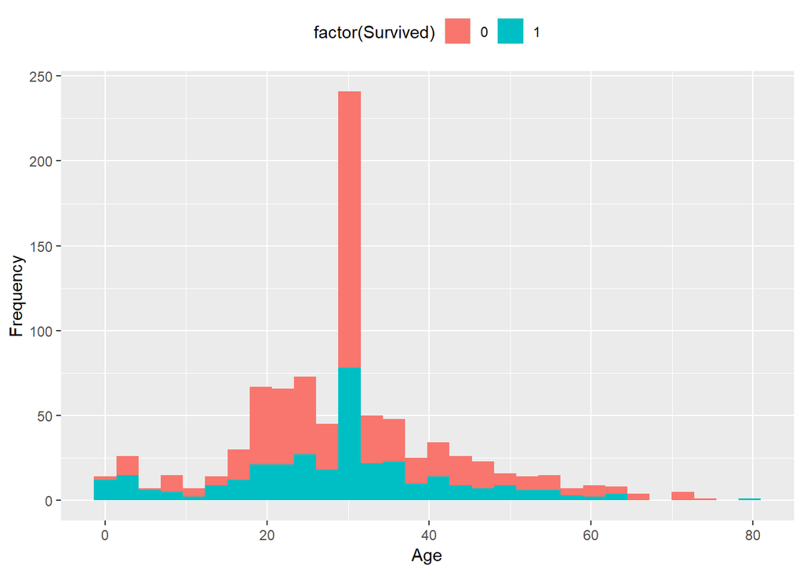

```r
#Age between 20 year and 40 year are high  survived rate and Elder peoples have low survival rate
ggplot(Titanic, aes(Age,fill = factor(Survived))) +
    geom_histogram()+ theme(legend.position="top")+ylab("Frequency")
```

#SEX vs Survival

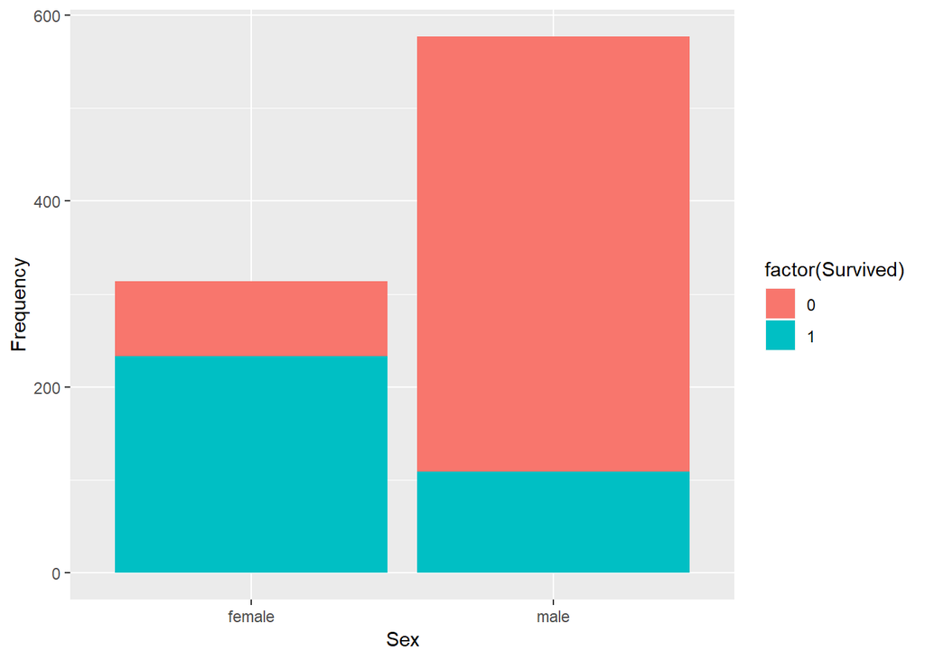

```r
#Male has low survival rate than Female.Female survived more than Male
ggplot(Titanic, aes(Sex,fill = factor(Survived))) +    geom_histogram(stat = "count")+ylab("Frequency")
```

```r
#Survival Rate
tapply( Titanic$Survived,Titanic$Sex, mean)
```

```
##    female      male
## 0.7420382 0.1889081
```

The survival rate of female is 0.74, while the survival rate of male is 0.18. #Embarked vs Survived

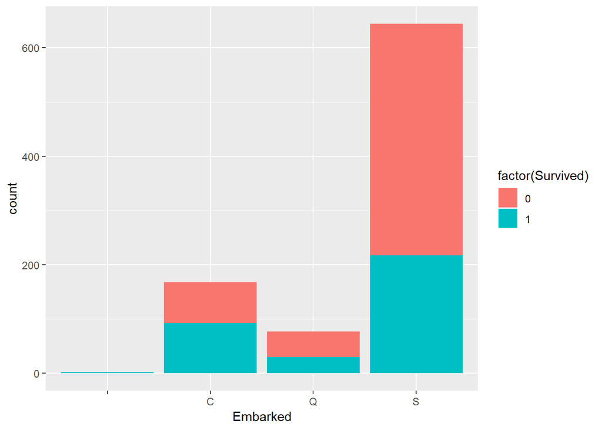

```r
ggplot(Titanic, aes(Embarked,fill = factor(Survived))) + geom_histogram(stat = "count")
```

#Pclass vs Survived

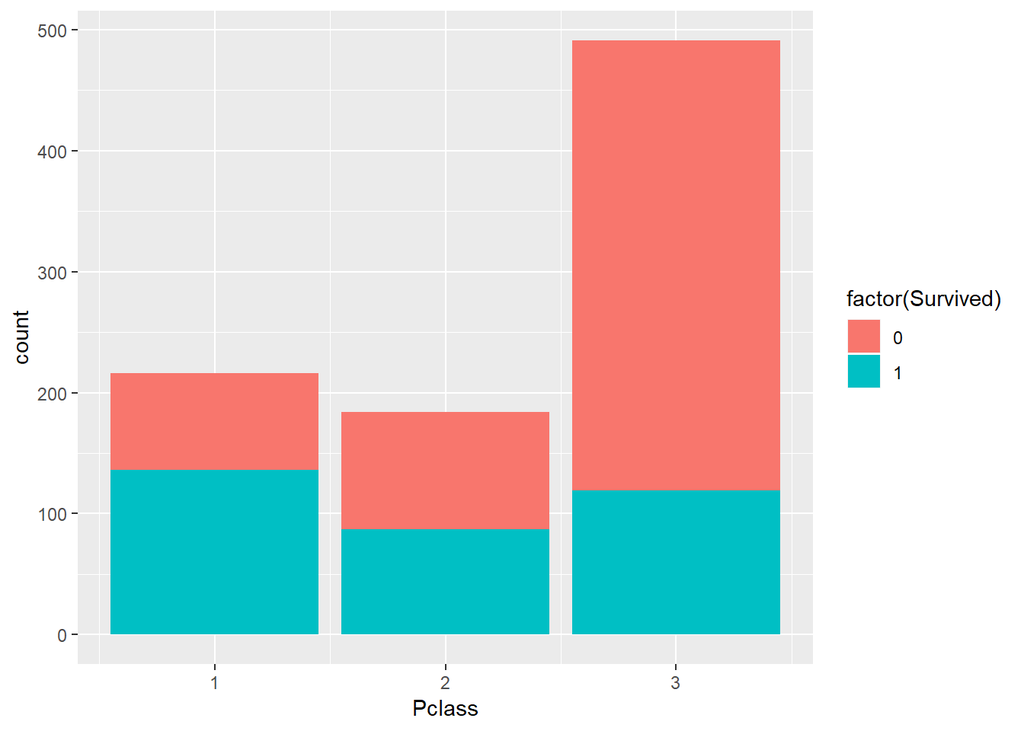

```r
ggplot(Titanic, aes(Pclass,fill = factor(Survived))) +  geom_histogram(stat = "count")
```

#Fare vs Survived

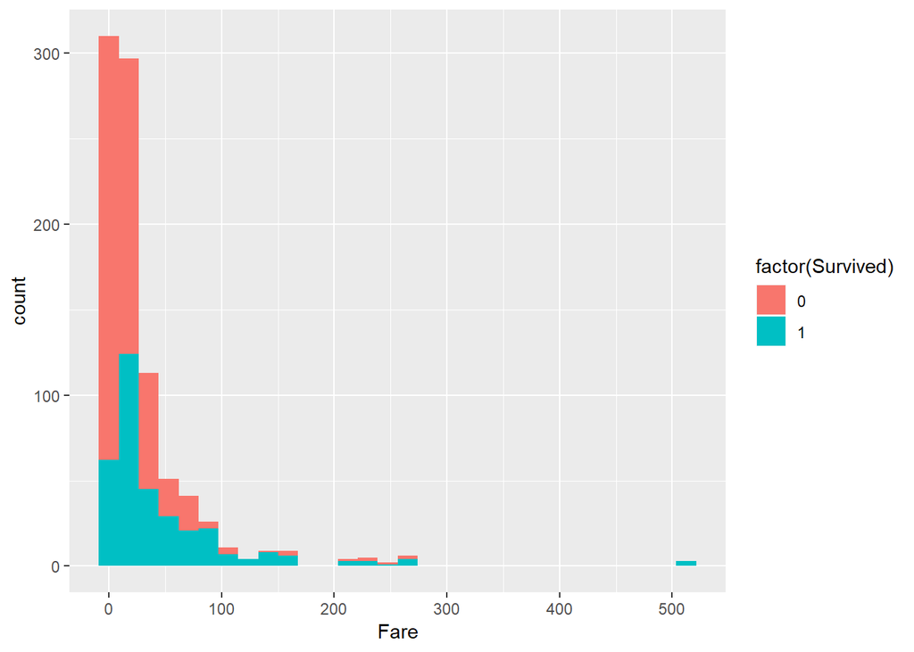

```r
ggplot(Titanic, aes(Fare,fill = factor(Survived))) +  geom_histogram()
```

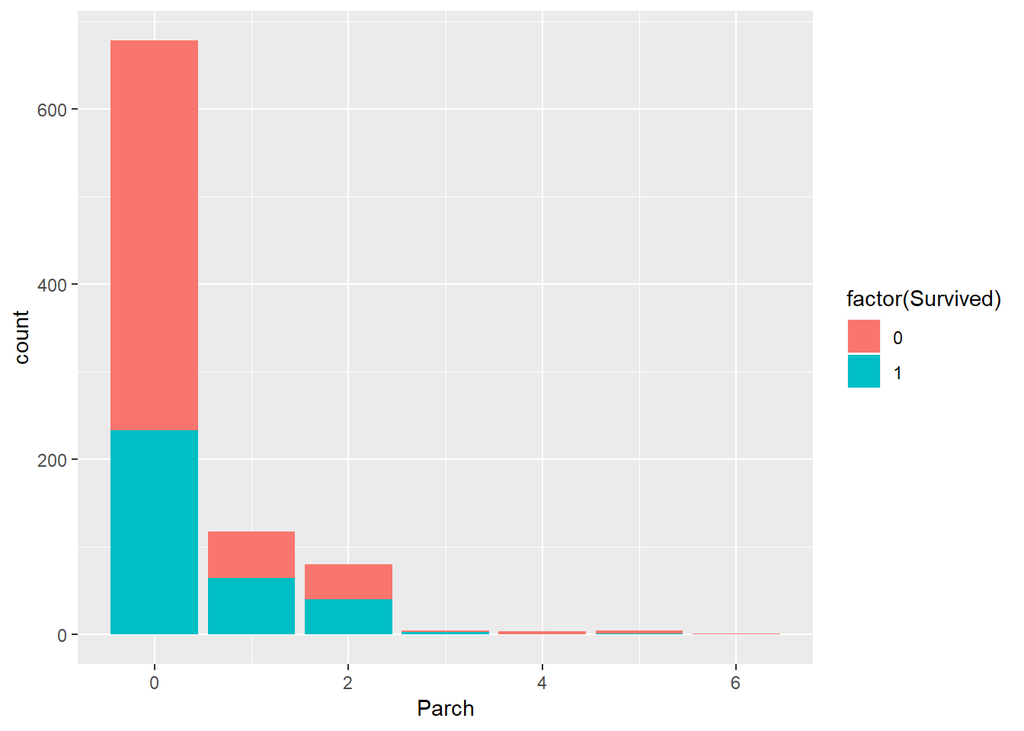

```r
ggplot(Titanic, aes(Parch,fill = factor(Survived))) +  geom_histogram(stat = "count")
```

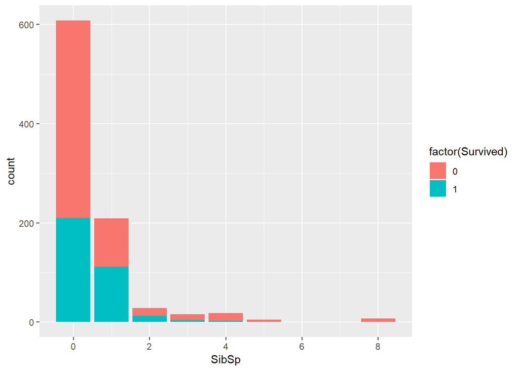

```r
ggplot(Titanic, aes(SibSp,fill = factor(Survived))) +  geom_histogram(stat = "count")
```

##LOGISTIC REGRESSION MODAL

```r
full=bind_rows(Titanic,Test)
train=full[1:891,]
test=full[892:1309,]
```

##Logit

```r
rf_model=glm(factor(Survived)  ~ Pclass + Age + Fare + Embarked, data = train ,family="binomial" )

rf_result=predict(rf_model, test,type="response")
rf_result = as.numeric(rf_result > 0.5)
table(rf_result, Test$Survived)
```

```
## < table of extent 2 x 0 >
```

```r
rf_solution = data.frame(PassengerId = test$PassengerId, Survived = rf_result)

write.csv(rf_solution, file = "submissions.csv", row.names = F)
```